# Pixel Binning Methods

## Choosing a binning method & parameters

The best binning method will depend on the dataset and the details being emphasized for analysis. The pros and cons listed above should help clarify what the effects of each method are likely to be, but there’s no harm in trying out a few different methods. I recommend starting out with the color histogram method unless you have a good reason to use k-means instead – the clusters may not look as intuitive, but the comparisons between images tend to have more statistical merit. Even if a color gets broken up across two bins, it will usually get broken up the same way in two different images, so the histograms will still look similar. And when a color is absent, that’s noted via an empty bin so we can compare presence to absence across images. That said, if your primary concern is extracting dominant colors in an image rather than making meaningful comparisons, k-means might be the way to go. If one were superior to the other in all respects, they wouldn’t both be included!

The nice thing about color clustering is that, unlike most statistical analyses, it’s trying to quantify something which is for the most part fairly visually intuitive – it should be obvious if the parameters you’re choosing are returning scores that don’t make a lot of sense, since we’re ranking images by color similarity. If you try k-means and it fails to cluster visually similar objects together, then k-means probably isn’t the right choice; if you choose too few bins and dissimilar objects are scoring as similar, you probably need to use more bins, and so on.

`imageClusterPipeline()` is a single function that goes from raw images to distance matrix in one line, making it easy to tweak parameters and methods. Setting `clusterMethod="hist"` or `clusterMethod="kmeans"` will toggle between the two methods.

## Cheatsheet

**Histogram method**

```r
par(mfrow=c(1, 3))
# Get and plot histogram for a single image
hist01 <- colordistance::getImageHist("Heliconius/Heliconius_08.jpeg", bins=2, plotting=T, title="RGB, 2 bins per channel", lower=lower, upper=upper)
```

```
## Using 2^3 = 8 total bins
```

```r
# Use the bin center as the cluster value instead of the average pixel location (note the difference between this and when binAvg=F)
hist02 <- colordistance::getImageHist("Heliconius/Heliconius_08.jpeg", bins=2, plotting=T, title="binAvg = F", lower=lower, upper=upper, binAvg=F)
```

```
## Using 2^3 = 8 total bins
```

```
## Using 8*1*2 = 16 bins
```

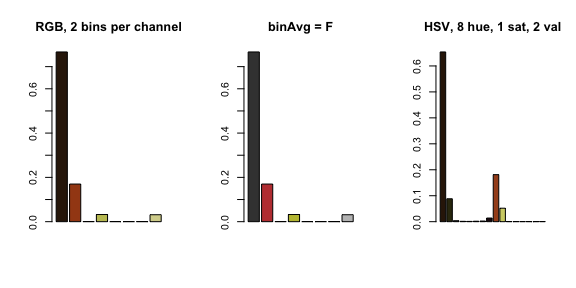

```r
# Use different number of bins for each channel; use HSV instead of RGB
hist03 <- colordistance::getImageHist("Heliconius/Heliconius_08.jpeg", bins=c(8, 1, 2), plotting=T, hsv=T, title="HSV, 8 hue, 1 sat, 2 val", lower=lower, upper=upper)
```

```r
# Get histograms for a set of images
histMulti <- colordistance::getHistList("Heliconius/", bins=2, plotting=F, lower=lower, upper=upper)
```

**K-means method**

```r
lower <- rep(0.8, 3)
upper <- rep(1, 3)

# Use defaults
kmeans01 <- colordistance::getKMeanColors("Heliconius/Heliconius_08.jpeg", n=3, plotting=F, lower=lower, upper=upper)
kmeansDF <- colordistance::extractClusters(kmeans01)

# Use a larger sample size
kmeans02 <- colordistance::getKMeanColors("Heliconius/Heliconius_08.jpeg", n=3, plotting=F, sampleSize = 30000, lower=lower, upper=upper)
kmeansDF2 <- colordistance::extractClusters(kmeans02)

# Don't return clusters as a dataframe
colordistance::getKMeanColors("Heliconius/Heliconius_08.jpeg", n=15, plotting=F, returnClust=F, lower=lower, upper=upper)
```

```r
# For whole dataset
kmeans03 <- colordistance::getKMeansList("Heliconius/", n=3, plotting=F, lower=lower, upper=upper)
kmeansList <- colordistance::extractClusters(kmeans03)
```

**Quick comparison**

```r
# If we use the same number of clusters for both the histogram and k-means methods, how different do the clusters look?
histExample <- colordistance::getHistList("Heliconius/", lower=lower, upper=upper)
```

```
## Using 3^3 = 27 total bins
```

```r
kmeansExample <- colordistance::extractClusters(colordistance::getKMeansList("Heliconius", bins=27, lower=lower, upper=upper))

colordistance::plotClustersMulti(histExample, title="Histogram method")

colordistance::plotClustersMulti(kmeansExample, title="K-means method")
```

[interactive chart not shown]

Meyer, Axel. 2006. “Repeating Patterns of Mimicry.” *PLOS Biology* 4 (10). Public Library of Science: 1–3. doi:10.1371/journal.pbio.0040341.

[^1]: Although the 0–255 intensity scale is common for RGB images, R reads images in on a 0–1 intensity scale; unless otherwise stated, the 0–1 scale should be assumed for any `colordistance` documentation and examples.